# disccoin

Varun Nadgir, Sam McGrail, Pete Eichman

October 21, 2017

## Introduction

Our goal is to build a React dashboard for a user to be able to check current statistics on various cryptocurrencies. We will also provide past data so the user can compare and explore trends. We are calling the current data from the [CoinMarketCap API](https://coinmarketcap.com/api/) and the past data was made avaiable on [Kaggle](https://www.kaggle.com/sudalairajkumar/cryptocurrencypricehistory) by user sudalairajkumar. In fact, he also compiled these data from CoinMarketCap, which saves us on API calls for past data and means the data will be consistent with the new data we pull. If we are successful in providing this dashboard, we would like to also create a Discord bot that can help with serving and tracking data.

## Preparing the Data

The Kaggle data is split up into multiple .csv files for each coin. Bitcoin and Etherium have very in-depth .csv’s with many columns, which will be useful later. For now, we are using the generic .csv files with 7 columns: Date, Day Opening Price, Day High, Day Low, Day Closing Price, Volume, and Market Cap. For convience, we added a new column to each of these files with the Coin name, since we plan on merging the files. The final .csv has all 11,070 records across now 8 variables.

## Exploring Plots

First of all, we can plot all of the coins’ Closing Price and see which are the ones with the most activity. We can expect Bitcoin to fall in this category, but are there others?

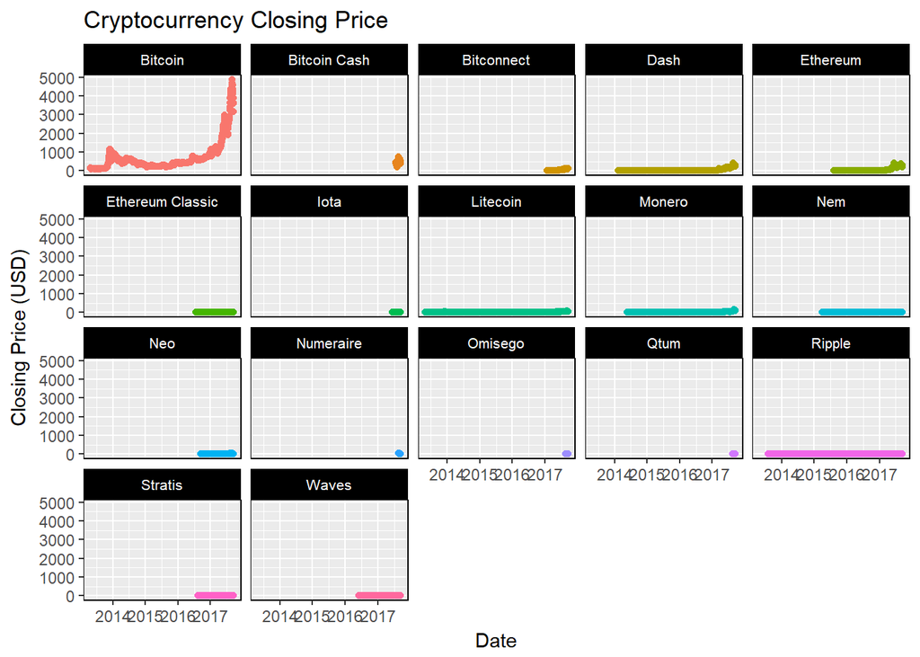

A lot of the coins have very sparse data, and since Bitcoin has had a lot of recent growth, it is making the scale too large for the other coins. We can tell, though, that Litecoin, Dash, Ethereum, and Ripple may be other coins to check out. For now, let’s check the Opening, High, Low, and Closing prices for Bitcoin only, and limit it to 2017 since it seems like that is where the most growth has been.

[interactive chart not shown]

With these data available, we will be able to make new calls to CoinMarketCap and append the new data to the existing data. Whether by colour coding or different plotting options, we can make the new data distinct from the older data.